# Third Week: Exploratory Data Analysis

LaLiga Analysis

Parand Alizadeh

2018-02-27 02:47:31

# تمرین سری سوم: از لالیگا تا لیگ برتر

> با استفاده از داده های لیگ دسته اول اسپانیا به سوالات زیر پاسخ دهید. از هر دو ابزار ggplot2 و highcharter برای این کار تصویرسازی استفاده نمایید.

۱. تعداد قهرمانی های تیم ها در تاریخ لالیگا را استخراج کرده و نمودار ستونی آنها را رسم کنید.

در کل تمرین معیار رتبه بندی تیم ها امتیاز، تفاضل گل و گل زده است.

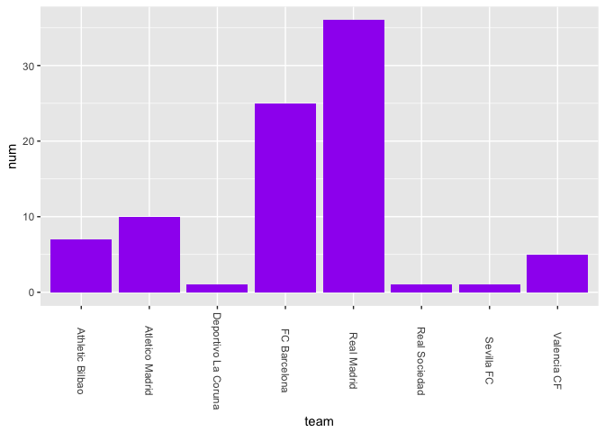

[interactive chart not shown]

۲. کسل کننده ترین لیگ و تیم را بیابید. نمودار ده تیم و ده فصل کسل کننده را رسم کنید.

مبنای کسل کنندگی تیم تعداد بازیهایی است که در آن گل نزده و تعداد بازیهایی که در آن ۰-۰ بازی کرده است. در یک فصل کسل کنندگی به تعداد بازیهای ۰-۰ و تعداد مساوی ها بستگی دارد.

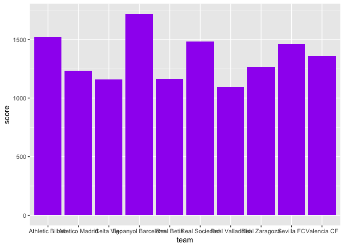

[interactive chart not shown]

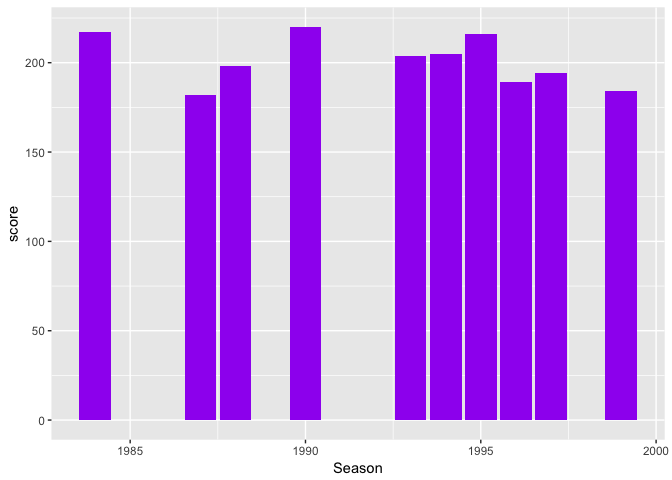

[interactive chart not shown]

۳. در چند درصد موارد قهرمان نیم فصل در پایان فصل قهرمان شده است؟

```
FALSE # A tibble: 1 x 3
FALSE    both   tot  rate
FALSE   <int> <int> <dbl>
FALSE 1    43    86  50.0
```

۴. در بین سال های ۲۰۰۱ تا ۲۰۱۰ گربه سیاه تیم های بزرگ چه تیم هایی بوده است؟

نمودار ۴ گربه سیاه برتر ۳ تیم قوی لالیگا

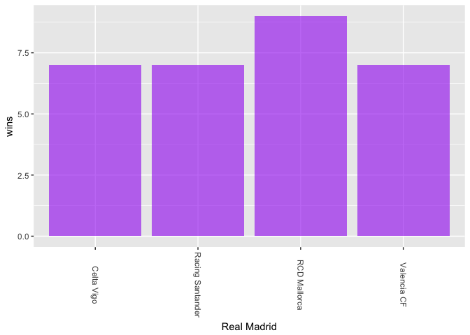

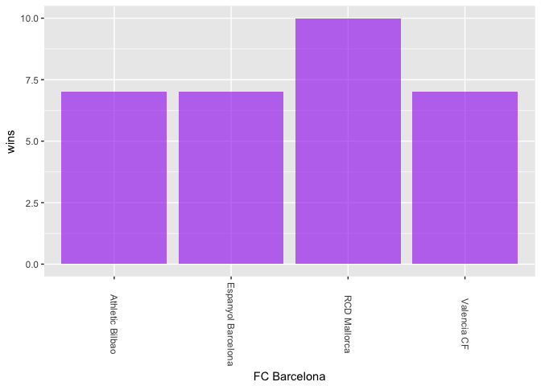

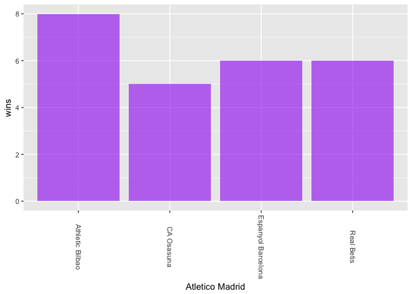

۵. در تاریخ لالیگا کدام تیم رکورددار زودترین قهرمانی است؟ همچنین کدام تیم مقتدرانه ترین قهرمانی را داشته است؟

زودترین قهرمانی (بر اساس فاصله از روز آخر بازیها)

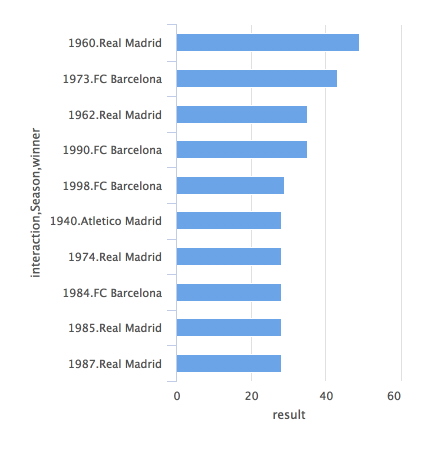

مقتدرانه ترین بردها:

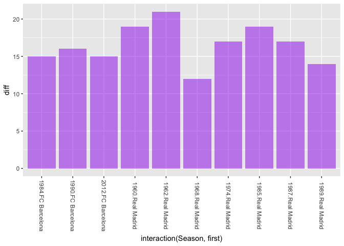

[interactive chart not shown]

۶. طولانی ترین نوار پیروزی مساوی و شکست مال چه تیم هایی است؟

[interactive chart not shown]

۷. زودترین سقوط مال کدام تیم بوده است؟

زودترین سقوط (بر اساس فاصله از روز آخر بازیها)

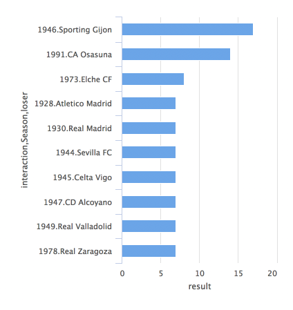

[figure not shown]

[figure not shown]

۱۰. سه آماره به همراه نمودار فردوسی پسند استخراج کنید.

بازی کردن در زمین خود چقدر تاثیر دارد؟ برای ۲۰ تیم برتر (تعداد برد بیشتر) نمودار نسبت برد در خانه به برد در زمین حریف را محاسبه کرده ایم.

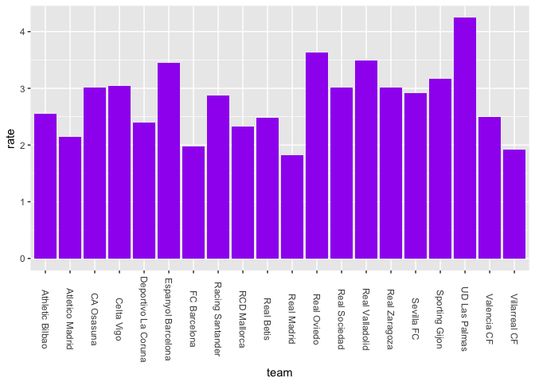

دربی الکلاسیکو را در نظر میگیریم. در چند درصد از فصل هایی که یک تیم تمام دربی های الکلاسیکو را برنده میشد این تیم قهرمان فصل میشود؟

```
FALSE # A tibble: 1 x 1
FALSE    rate
FALSE   <dbl>
FALSE 1  60.0
```

5 تیم برتر (از نظر تعداد بار قهرمان شدن) را در نظر بگیرید. جدول تعداد بردهای هردو تیم نسبت به هم را رسم کنید.

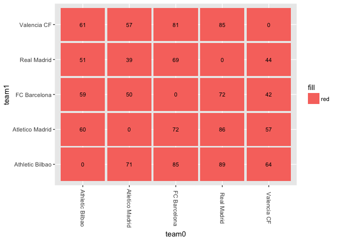